# Tanguro Spectral Mixture

Por: Eduardo Q Marques

15 de maio de 2020

## Load data

```r
library(raster)
library(rasterVis)
library(rgdal)
library(viridis)

setwd('C:/Users/Eduardo Q Marques/Documents/My Jobs/Doutorado/Deposito/Banco de Dados Tanguro/Fraction_Landsat')
dir()
```

```
##  [1] "CLASlite_v3.3 User Guide.pdf"    "Fractional Images.R"
##  [3] "L8_224069_20140705_frac"         "L8_224069_20140705_frac.aux.xml"
##  [5] "L8_224069_20140705_frac.hdr"     "L8_224069_20140705_frac.rar"
##  [7] "L8_224069_20140721_frac.rar"     "L8_224069_20140806_frac.rar"
##  [9] "Tanguro Spectral Mixture.Rmd"    "Tanguro_Spectral_Mixture.html"
## [11] "Tanguro_Spectral_Mixture.Rmd"
```

```r
frac = brick("L8_224069_20140705_frac")

area1 = readOGR(dsn = 'C:/Users/Eduardo Q Marques/Documents/My Jobs/Doutorado/Deposito/Banco de Dados Tanguro/Shapes', layer = 'Polygon_A_B_C')
```

## The bands

Fraction images have 7 bands:  
Band 1 - Fractional cover of bare substrate (S), expressed as a percentage (0-100%)  
Band 2 - Fractional cover of photosynthetic vegetation (PV), expressed as a percentage (0-100%)  
Band 3 - Fractional cover of non-photosynthetic vegetation (NPV), expressed as a percentage (0-100%)  
Band 4 - Uncertainty of the S fraction, expressed as the standard deviation of AutoMCU iterations  
Band 5 - Uncertainty of the PV fraction, expressed as the standard deviation of AutoMCU iterations  
Band 6 - Uncertainty of the NPV fraction, expressed as the standard deviation of AutoMCU iterations  
Band 7 - Total error, expressed as the RMSE of the modeled versus observed reflectance signature

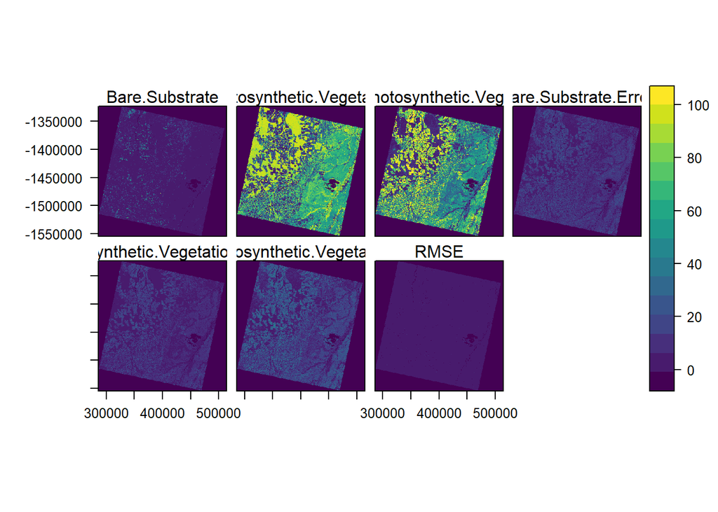

```r
levelplot(frac, margin = FALSE, col.regions = viridis(100))
```

## Tanguro time-series

The images that Sonaira is working on comprise the entire Landsat scene. That way she takes the entire Tanguro farm. When it finishes processing we will have a time series of all Tanguro from 2000 to 2019.

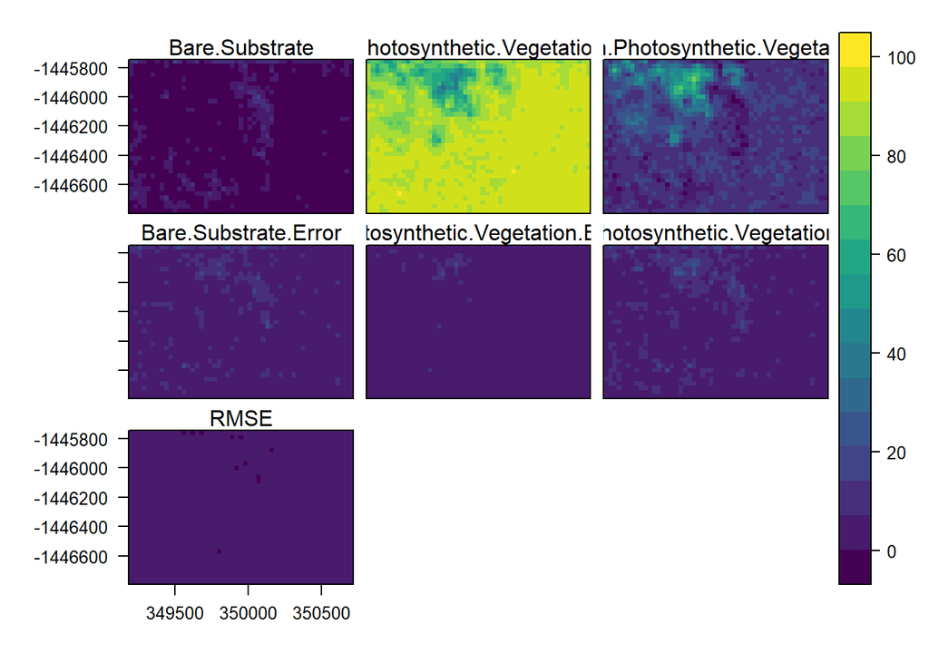

```r
area1 = spTransform(area1, crs(frac))
frac = crop(frac, area1)

levelplot(frac, margin = FALSE, col.regions = viridis(100))
```

## NPV

Next week I will have more images and I will try to explore a little more and start some comparisons with the vegetation indices of Landsat and Hyperion.

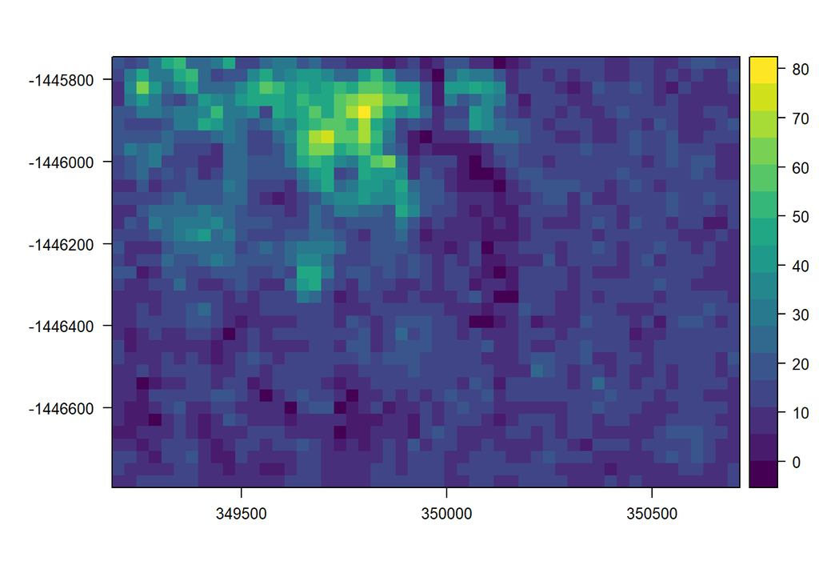

```r
levelplot(frac[[3]], margin = FALSE, col.regions = viridis(100))
```